# Add your Name: Francisco Javier Diaz Roa

# StudentID: 8975938

# Please submit the notebook and HTML version of your notebook to EConestoga Dropbox

# **Question 1 - Pandas** (12 marks)

- Using RegularSeasonCompactResults.csv
- and Teams.csv

```python
# Using RegularSeasonCompactResults.csv
# 1- Create a filter to show if there are any draw matches
# 2- Apply the filter to the dataframe
# 3- SHOW the dataframe length or count (4 marks)
# load the data from the file RegularSeasonCompactResults.csv
import pandas as pd
df = pd.read_csv('RegularSeasonCompactResults.csv')
print(df.head())

# Create a filter to show if there are any draw matches
draw = df['Wscore'] == df['Lscore']
# Apply the filter to the dataframe
df_draw = df[draw]
# SHOW the dataframe length or count
print(len(df_draw))
```

```
   Season  Daynum  Wteam  Wscore  Lteam  Lscore Wloc  Numot
0    1985      20   1228      81   1328      64    N      0
1    1985      25   1106      77   1354      70    H      0
2    1985      25   1112      63   1223      56    H      0
3    1985      25   1165      70   1432      54    H      0
4    1985      25   1192      86   1447      74    H      0
0
```

```python
# Using RegularSeasonCompactResults.csv
# 1- Create a filter showing the entries where the winningteamID= 1400- (last two digits of your id)
# 2- Create another filter for the season of 2013
# 3- Apply the filter to the dataframe
# 4- Show the resulted dataframe (4 marks)
# (Example: IF your id is 8000021, the winning team id = 1400-21= 1389)

# Create a filter showing the entries where the winningteamID= 1400- (last two digits of your id)
winningteamID = df['Wteam'] == 1400-38
# Create another filter for the season of 2013
season = df['Season'] == 2013
# Apply the filter to the dataframe
df_win = df[winningteamID & season]
# Show the resulted dataframe
print(df_win)
```

```
        Season  Daynum  Wteam  Wscore  Lteam  Lscore Wloc  Numot
124413    2013      14   1362      67   1110      53    A      0
124662    2013      19   1362      79   1162      59    H      0
124869    2013      25   1362      78   1285      68    H      0
125048    2013      29   1362      81   1385      65    H      0
125719    2013      50   1362      67   1190      49    N      0
126775    2013      75   1362      62   1258      53    H      0
126968    2013      80   1362      75   1339      72    A      0
127424    2013      89   1362      86   1337      78    A      0
127729    2013      96   1362      99   1140      87    A      0
128249    2013     108   1362      61   1258      59    A      0
128368    2013     110   1362      64   1337      58    H      0
128557    2013     115   1362      83   1360      70    A      0
129119    2013     129   1362      73   1297      68    H      0
```

```python
# Using RegularSeasonCompactResults.csv & Teams.csv
# 1- Load and merge both dataframes
# 2- Where the merge is on WinningTeamId (RegularSeasonCompactResults) and TeamId (Teams.csv)
# 3- Name the dataframe: DFCombined
# 4- Show the top 3 rows (4 marks)
# TODO: Your code should be here

# Load and merge both dataframes
df_teams = pd.read_csv('Teams.csv')
DFCombined = pd.merge(df, df_teams, left_on='Wteam', right_on='Team_Id')
# where the merge is on WinningTeamId (RegularSeasonCompactResults) and TeamId (Teams.csv)
# show the top 3 rows
print(DFCombined.head(3))
```

```
   Season  Daynum  Wteam  Wscore  Lteam  Lscore Wloc  Numot  Team_Id  \
0    1985      20   1228      81   1328      64    N      0     1228
1    1985      25   1106      77   1354      70    H      0     1106
2    1985      25   1112      63   1223      56    H      0     1112

    Team_Name
0    Illinois
1  Alabama St
2     Arizona
```

# **Question 2 - Visualizations**

## **Part I**

Using the following dataset: https://raw.githubusercontent.com/mwaskom/seaborn-data/master/penguins.csv choose the most convenient graph to show the following, each question in **one** graph, using the library of your choice: (18 Marks)

**1. The relationship between the penguin's bill length and bill depth for each species.** (5 marks)

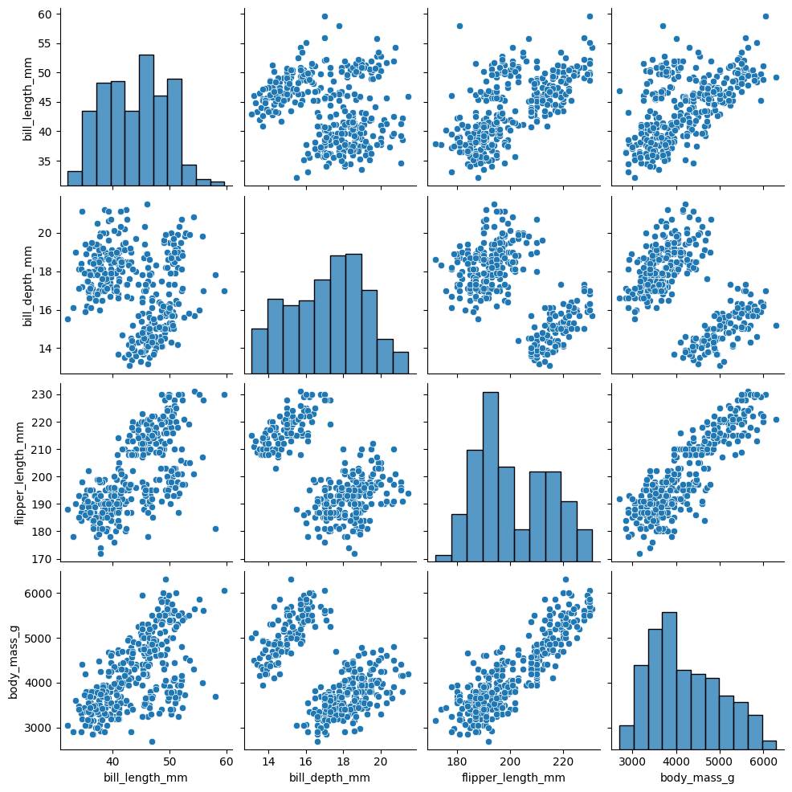

```python
## TODO: Check your attributes, make a graph using Matplotlib or Seaborn to show the relationship needed
# load the data from penguins.csv using pandas
import matplotlib.pyplot as plt
import seaborn as sns
df_penguins = pd.read_csv('penguins.csv')

# make a graph using Matplotlib or Seaborn to show the relationship needed
sns.pairplot(df_penguins)
plt.show()
```

**What do you observe from the graph?** (2 marks)

**Why did you choose this type of graph?** (2 marks)

Your answer here:

- I chose pairplot because it shows the relationship between the different attributes in the dataset.

**2. Suitable graph of the mean BMI (BMI not body_mass weight_in_kg/height(m2)) of female and male penguins. (Assume the height is the flipper length)** (5 marks)

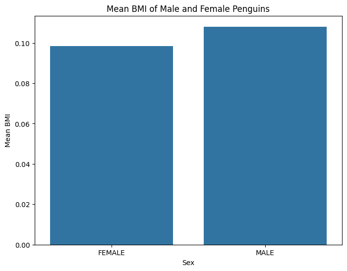

```python
# Drop rows with missing values
penguins_df = df_penguins.dropna(subset=['flipper_length_mm', 'body_mass_g', 'sex'])

# Calculate BMI
penguins_df['BMI'] = penguins_df['body_mass_g'] / (penguins_df['flipper_length_mm'] ** 2)

# Calculate mean BMI for each sex
mean_bmi_df = penguins_df.groupby('sex')['BMI'].mean().reset_index()

# Plot the mean BMI for each sex using seaborn
plt.figure(figsize=(8, 6))
sns.barplot(x='sex', y='BMI', data=mean_bmi_df)
plt.title('Mean BMI of Male and Female Penguins')
plt.xlabel('Sex')
plt.ylabel('Mean BMI')
plt.show()
```

**What do you observe from the graph?** (2 marks)

**Why did you choose this type of graph?** (2 marks)

Your answer here:

- Bar plots are excellent for comparing the means or averages of different groups. In this case, we wanted to compare the mean BMI between male and female penguins.
- Bar plots are straightforward and easy to interpret. They provide a clear visual distinction between the two groups (male and female penguins), making it easy to see the difference in mean BMI.

## **Part II**

You can find the csv file that contains the museum visitors data here: ./CSVs/museum_visitors.csv (8 marks)

Review the data by taking a look at a few of the rows.

```python
# load the data from museum_visitors.csv using pandas
df_museum = pd.read_csv('museum_visitors.csv')
# print the first 5 rows of the dataframe
print(df_museum.head())
```

```
         Date  Avila Adobe  Firehouse Museum  Chinese American Museum  \
0  2014-01-01        24778              4486                     1581
1  2014-02-01        18976              4172                     1785
2  2014-03-01        25231              7082                     3229
3  2014-04-01        26989              6756                     2129
4  2014-05-01        36883             10858                     3676

   America Tropical Interpretive Center
0                                  6602
1                                  5029
2                                  8129
3                                  2824
4                                 10694
```

Convince the museum board

The Firehouse Museum claims they ran an event in 2014 that brought an incredible number of visitors, and that they should get extra budget to run a similar event again. The other museums think these types of events aren't that important, and budgets should be split purely based on recent visitors on an average day.

To show the museum board how the event compared to regular traffic at each museum, create a suitable chart that shows how the number of visitors to each museum evolved over time. (4 marks)

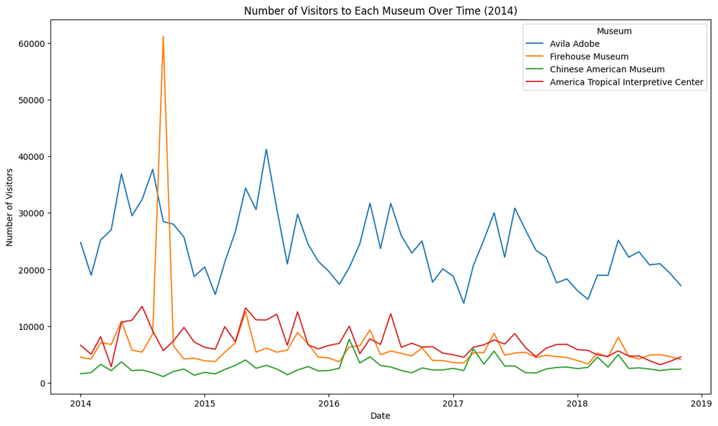

```python
#Your solution here
# Convert the 'Date' column to datetime format
df_museum['Date'] = pd.to_datetime(df_museum['Date'])

# Set the 'Date' column as the index
df_museum.set_index('Date', inplace=True)

# Plot the number of visitors to each museum over time
plt.figure(figsize=(14, 8))
for column in df_museum.columns:
    plt.plot(df_museum.index, df_museum[column], label=column)

plt.title('Number of Visitors to Each Museum Over Time (2014)')
plt.xlabel('Date')
plt.ylabel('Number of Visitors')
plt.legend(title='Museum')
plt.show()
```

What did you observe from the graph? (2 marks)

Why did you choose this type of graph? (2 marks)

## **PART III**

Using the file in ./CSVs/gas_prices.csv  
Use a suitable plot/graph that will show the relationship between the gas price for each country (vs others) over all years. (8 marks)

First, review the data by taking a look at a few of the rows.

```python
# Your solution here
gas_prices_df = pd.read_csv('gas_prices.csv')

# print the first 5 rows of the dataframe
print(gas_prices_df.head())
```

```
   Year  Australia  Canada  France  Germany  Italy  Japan  Mexico  \
0  1990        NaN    1.87    3.63     2.65   4.59   3.16    1.00
1  1991       1.96    1.92    3.45     2.90   4.50   3.46    1.30
2  1992       1.89    1.73    3.56     3.27   4.53   3.58    1.50
3  1993       1.73    1.57    3.41     3.07   3.68   4.16    1.56
4  1994       1.84    1.45    3.59     3.52   3.70   4.36    1.48

   South Korea    UK   USA
0         2.05  2.82  1.16
1         2.49  3.01  1.14
2         2.65  3.06  1.13
3         2.88  2.84  1.11
4         2.87  2.99  1.11
```

Then Plot using the most suitable plot on your opinion (5 marks)

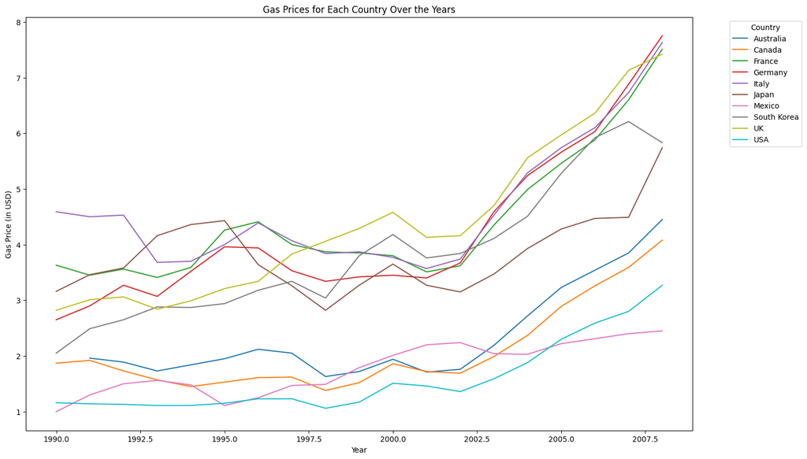

```python
## Your solution here
# Melt the dataframe to have 'Year' and 'Country' as separate columns
melted_gas_prices_df = gas_prices_df.melt(id_vars=['Year'], var_name='Country', value_name='Gas_Price')

# Plot the gas prices for each country over all years using seaborn
plt.figure(figsize=(16, 10))
sns.lineplot(data=melted_gas_prices_df, x='Year', y='Gas_Price', hue='Country')

plt.title('Gas Prices for Each Country Over the Years')
plt.xlabel('Year')
plt.ylabel('Gas Price (in USD)')
plt.legend(title='Country', bbox_to_anchor=(1.05, 1), loc='upper left')
plt.show()
```

Is there anything interesting observed from the plot/graph? (1 mark)

Your answer here

- Most countries show a general upward trend in gas prices over the years, indicating an increase in gas prices globally.
- Italy and France consistently have some of the highest gas prices compared to other countries.
- South Korea and Japan show more fluctuations in gas prices, indicating potential volatility in their gas markets.
- Germany shows a sharp increase around the early 2000s, which could be due to policy changes or economic factors.

Why did you choose this type of graph? (2 marks)